# Practical Machine Learning Course Project

Allison Silcox

January, 2015

Background

Using devices such as Jawbone Up, Nike FuelBand, and Fitbit it is now possible to collect a large amount of data about personal activity relatively inexpensively. These type of devices are part of the quantified self movement - a group of enthusiasts who take measurements about themselves regularly to improve their health, to find patterns in their behavior, or because they are tech geeks. One thing that people regularly do is quantify how much of a particular activity they do, but they rarely quantify how well they do it. In this project, our goal is to use data from accelerometers on the belt, forearm, arm, and dumbell of 6 participants. They were asked to perform barbell lifts correctly and incorrectly in 5 different ways. More information is available from the website here: http://groupware.les.inf.puc-rio.br/har (see the section on the Weight Lifting Exercise Dataset).

Project Goal

The goal of the project is to build an algorithm to predict the manner in which the exercise was done (the “classe” variable in the dataset) from the other available data - the measurements taken during the exercise.

Data

The training data for this project are available here: https://d396qusza40orc.cloudfront.net/predmachlearn/pml-training.csv

The test data are available here: https://d396qusza40orc.cloudfront.net/predmachlearn/pml-testing.csv

The “classe” variable in the training set is the manner in which the exercise (Unilateral Dumbbell Biceps Curl) was done: exactly according to the specification (Class A), throwing the elbows to the front (Class B), lifting the dumbbell only halfway (Class C), lowering the dumbbell only halfway (Class D) and throwing the hips to the front (Class E). Read more: http://groupware.les.inf.puc-rio.br/har#ixzz3P2ePf9CV

Project assignment: use any of the other variables to predict class asignment (the ‘classe’ variable). Create a report describing how the model was built, how cross validation was used, what the expected out of sample error is, and choices made in modeling. Then use the prediction model to predict 20 different test cases.

```r
# download data files
#download.file("http://d396qusza40orc.cloudfront.net/predmachlearn/pml-training.csv", destfile = "pml-training.csv")
#download.file("http://d396qusza40orc.cloudfront.net/predmachlearn/pml-testing.csv", destfile = "pml-testing.csv")
# read files into R
pml_training <- read.csv(file = 'pml-training.csv',na.strings = c('NA','#DIV/0!','',' '))
pml_testing <- read.csv(file = 'pml-testing.csv',na.strings = c('NA','#DIV/0!','',' '))
```

Data prep and cleaning: Inspection of the training data shows that rows where the variable new_window=‘yes’ (usually tied to a value change in num_window) appear to be a summary row for the prior num_window values (possibly individual observations) and a large number of fields for rows where new_window=‘no’ have invalid (NA, missing) data which is populated only for rows where new_window=‘yes’. Given that all test cases have new_window=‘no’ values, the rows with new_window=‘yes’ and the asociated columns with near zero values were excluded, as were the descriptive/datetime columns 1-7.

```r
library(caret, quietly=TRUE)
pml_training2<-pml_training[pml_training$new_window=='no',-c(1:7)]
training_nzv<- nearZeroVar(pml_training2, saveMetrics=TRUE)
pml_training3<-pml_training2[,!training_nzv$nzv]
```

Training and validation data sets: To build and then validate the model the training dataset was split into training (70%) and validation (30%) sets.

```r
set.seed(5486)
inTrain <- createDataPartition(y=pml_training3$classe, p = 0.7)[[1]]
training = pml_training3[ inTrain,]
validation = pml_training3[-inTrain,]
```

In exploring the data source website for background information - e.g. explanation of the data - measurements, classifications, etc. - the associated research paper described success using a random forest classification approach. Random forests have been shown to be a top performing algorithm for classification predictions and this method proved very accurate here. (Note: a CART approach - single classification tree rather than ensembling trees as in random forests - was also tested using the caret R package (method=“rpart”) but produced much lower accuracy - see Appendix).

A random forest model was built on the training dataset using the caret R package with method=“rf”. 4-fold cross-validation was used in building the model (repeats=1 cv default). The selected final model (selected based on highest Accuracy) shows Accuracy of 0.9894 and OOB (out-of-bag) estimate of error rate of 0.71%.

```r
model_crf <- train(classe ~ .,data = training, method = 'rf',
                trControl = trainControl(method = "cv",number = 4,))
model_crf
```

```
## Random Forest
##
## 13453 samples
##    52 predictor
##     5 classes: 'A', 'B', 'C', 'D', 'E'
##
## No pre-processing
## Resampling: Cross-Validated (4 fold)
##
## Summary of sample sizes: 10090, 10089, 10089, 10091
##
## Resampling results across tuning parameters:
##
##   mtry  Accuracy   Kappa      Accuracy SD  Kappa SD
##    2    0.9893708  0.9865520  0.002392944  0.003027900
##   27    0.9893708  0.9865525  0.002132851  0.002697112
##   52    0.9797079  0.9743272  0.004030766  0.005094960
##
## Accuracy was used to select the optimal model using  the largest value.
## The final value used for the model was mtry = 2.
```

```r
model_crf$finalModel
```

```
##
## Call:
##  randomForest(x = x, y = y, mtry = param$mtry)
##                Type of random forest: classification
##                      Number of trees: 500
## No. of variables tried at each split: 2
##
##         OOB estimate of  error rate: 0.71%
## Confusion matrix:
##      A    B    C    D    E class.error
## A 3826    3    0    0    1 0.001044386
## B   16 2581    6    0    0 0.008451786
## C    0   24 2318    5    0 0.012356199
## D    0    0   31 2169    3 0.015433500
## E    0    0    2    5 2463 0.002834008
```

The deveoped model was then applied to the validation set. A confusion matrix comparing the actual to predicted classifications in the validation data set shows an Accurcy of 0.9941 for the validation set.

```r
pred_crf <- predict(model_crf,validation)
cm_crf <- confusionMatrix(pred_crf,validation$classe)
cm_crf
```

```
## Confusion Matrix and Statistics
##
##           Reference
## Prediction    A    B    C    D    E
##          A 1640    4    0    0    0
##          B    1 1111    9    0    0
##          C    0    0  995   15    3
##          D    0    0    1  928    0
##          E    0    0    0    1 1055
##
## Overall Statistics
##
##                Accuracy : 0.9941
##                  95% CI : (0.9918, 0.9959)
##     No Information Rate : 0.2847
##     P-Value [Acc > NIR] : < 2.2e-16
##
##                   Kappa : 0.9925
##  Mcnemar's Test P-Value : NA
##
## Statistics by Class:
##
##                      Class: A Class: B Class: C Class: D Class: E
## Sensitivity            0.9994   0.9964   0.9900   0.9831   0.9972
## Specificity            0.9990   0.9978   0.9962   0.9998   0.9998
## Pos Pred Value         0.9976   0.9911   0.9822   0.9989   0.9991
## Neg Pred Value         0.9998   0.9991   0.9979   0.9967   0.9994
## Prevalence             0.2847   0.1935   0.1744   0.1638   0.1836
## Detection Rate         0.2846   0.1928   0.1727   0.1610   0.1831
## Detection Prevalence   0.2853   0.1945   0.1758   0.1612   0.1832
## Balanced Accuracy      0.9992   0.9971   0.9931   0.9914   0.9985
```

Out of Sample Error: i.e. the error rate you get on a new data set = 1 - Accuracy for predictions on new data (test/validation set). The expected Out of Sample Error here is 1-0.9941 = 0.0059 (0.59%).

```r
1-cm_crf$overall["Accuracy"]   ## Out of Sample Error = 1 - Accuracy
```

```
##    Accuracy
## 0.005899705
```

Applying the prediction algorithm to the 20 cases in the provided testing sample: First clean the testing dataset and then apply the prediction model.

```r
pml_testing2<-pml_testing[pml_testing$new_window=='no',-c(1:7)]
testing_nzv<- nearZeroVar(pml_testing2, saveMetrics=TRUE)
pml_testing3<-pml_testing2[,!testing_nzv$nzv]
pred_test <- predict(model_crf,pml_testing)
pred_test
```

```
##  [1] B A B A A E D B A A B C B A E E A B B B
## Levels: A B C D E
```

********************************************** Appendix: **********************************************

Plot of final random forest model error: classification error decreases as # trees increases. Black = OOB error, colors = each of the classification values (A,B,C,D,E).

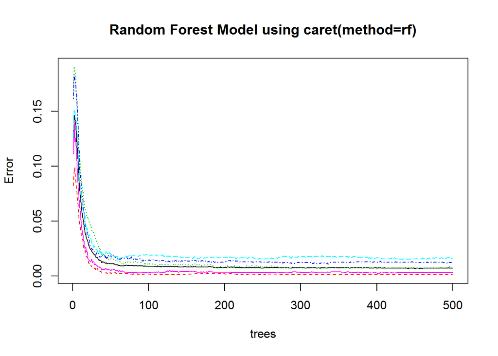

```r
plot(model_crf$finalModel,main="Random Forest Model using caret(method=rf)")
```

Top contributing predictors in the final model:

```r
varImp(model_crf)
```

```
## rf variable importance
##
##   only 20 most important variables shown (out of 52)
##
##                   Overall
## roll_belt          100.00
## yaw_belt            82.51
## magnet_dumbbell_z   71.75
## pitch_belt          65.58
## magnet_dumbbell_y   63.95
## pitch_forearm       62.17
## magnet_dumbbell_x   56.28
## roll_forearm        51.02
## accel_dumbbell_y    45.57
## magnet_belt_z       45.53
## magnet_belt_y       44.32
## roll_dumbbell       43.52
## accel_belt_z        43.30
## accel_dumbbell_z    41.33
## roll_arm            36.27
## accel_forearm_x     36.10
## accel_dumbbell_x    30.74
## total_accel_belt    30.38
## yaw_dumbbell        30.31
## gyros_belt_z        30.13
```

CART classification model using caret(method=“rpart”): Accuracy on the validation set is much lower than random forest method (0.4951).

```r
model_rpart <- train(classe ~ .,data = training,method="rpart")
model_rpart
```

```
## CART
##
## 13453 samples
##    52 predictor
##     5 classes: 'A', 'B', 'C', 'D', 'E'
##
## No pre-processing
## Resampling: Bootstrapped (25 reps)
##
## Summary of sample sizes: 13453, 13453, 13453, 13453, 13453, 13453, ...
##
## Resampling results across tuning parameters:
##
##   cp          Accuracy   Kappa      Accuracy SD  Kappa SD
##   0.03574769  0.5074424  0.3574886  0.01394687   0.02082401
##   0.05989123  0.4103986  0.2000806  0.06270850   0.10374585
##   0.11545256  0.3421274  0.0888528  0.03817119   0.05667656
##
## Accuracy was used to select the optimal model using  the largest value.
## The final value used for the model was cp = 0.03574769.
```

```r
print(model_rpart$finalModel)
```

```
## n= 13453
##
## node), split, n, loss, yval, (yprob)
##       * denotes terminal node
##
##  1) root 13453 9623 A (0.28 0.19 0.17 0.16 0.18)
##    2) roll_belt< 130.5 12328 8505 A (0.31 0.21 0.19 0.18 0.11)
##      4) pitch_forearm< -33.95 1114    5 A (1 0.0045 0 0 0) *
##      5) pitch_forearm>=-33.95 11214 8500 A (0.24 0.23 0.21 0.2 0.12)
##       10) magnet_dumbbell_y< 439.5 9487 6833 A (0.28 0.18 0.24 0.19 0.11)
##         20) roll_forearm< 123.5 5919 3543 A (0.4 0.18 0.18 0.17 0.062) *
##         21) roll_forearm>=123.5 3568 2375 C (0.078 0.18 0.33 0.23 0.18) *
##       11) magnet_dumbbell_y>=439.5 1727  853 B (0.035 0.51 0.041 0.22 0.2) *
##    3) roll_belt>=130.5 1125    7 E (0.0062 0 0 0 0.99) *
```

```r
confusionMatrix(predict(model_rpart,validation),validation$classe)
```

```
## Confusion Matrix and Statistics
##
##           Reference
## Prediction    A    B    C    D    E
##          A 1496  460  467  414  147
##          B   20  385   37  171  139
##          C  119  270  501  359  301
##          D    0    0    0    0    0
##          E    6    0    0    0  471
##
## Overall Statistics
##
##                Accuracy : 0.4951
##                  95% CI : (0.4821, 0.508)
##     No Information Rate : 0.2847
##     P-Value [Acc > NIR] : < 2.2e-16
##
##                   Kappa : 0.3401
##  Mcnemar's Test P-Value : NA
##
## Statistics by Class:
##
##                      Class: A Class: B Class: C Class: D Class: E
## Sensitivity            0.9116  0.34529  0.49851   0.0000  0.44518
## Specificity            0.6390  0.92104  0.77953   1.0000  0.99872
## Pos Pred Value         0.5013  0.51197  0.32323      NaN  0.98742
## Neg Pred Value         0.9478  0.85432  0.88037   0.8362  0.88895
## Prevalence             0.2847  0.19348  0.17439   0.1638  0.18358
## Detection Rate         0.2596  0.06681  0.08693   0.0000  0.08173
## Detection Prevalence   0.5178  0.13049  0.26896   0.0000  0.08277
## Balanced Accuracy      0.7753  0.63317  0.63902   0.5000  0.72195
```

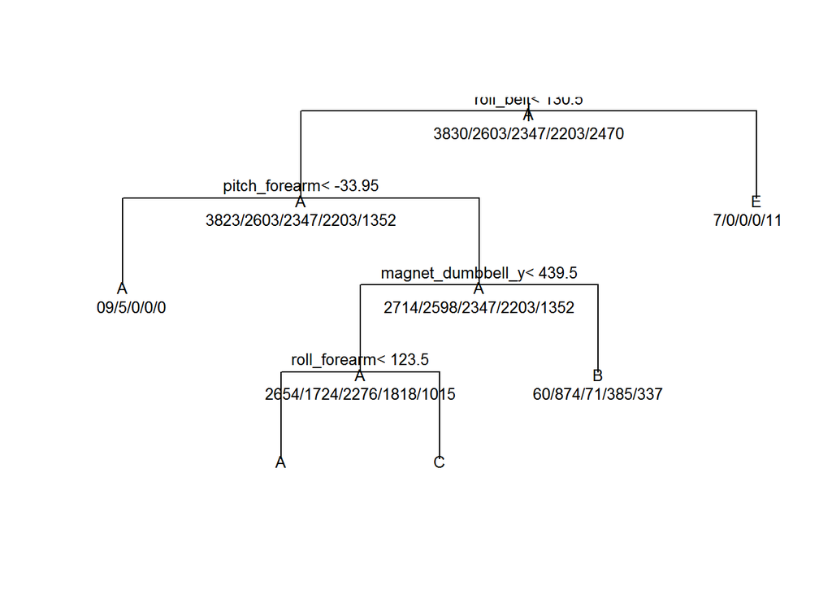

```r
plot(model_rpart$finalModel, uniform=TRUE)
text(model_rpart$finalModel, use.n=TRUE, all=TRUE, cex=.8)
```